# Risk Factor Analysis

## Outcome Variable

**Outcome Variable:** stunted

## Predictor Variables

**Intervention Variable:** hdlvry

**Adjustment Set:**

unadjusted

## Stratifying Variables

The analysis was stratified on these variable(s):

- agecat
- studyid
- country

## Data Summary

| agecat | studyid | country | hdlvry | stunted | n_cell | n |
| --- | --- | --- | --- | --- | --- | --- |
| Birth | ki1000108-CMC-V-BCS-2002 | INDIA | 0 | 0 | 74 | 90 |
| Birth | ki1000108-CMC-V-BCS-2002 | INDIA | 0 | 1 | 16 | 90 |
| Birth | ki1000108-CMC-V-BCS-2002 | INDIA | 1 | 0 | 0 | 90 |
| Birth | ki1000108-CMC-V-BCS-2002 | INDIA | 1 | 1 | 0 | 90 |
| Birth | ki1000108-IRC | INDIA | 0 | 0 | 337 | 388 |
| Birth | ki1000108-IRC | INDIA | 0 | 1 | 44 | 388 |
| Birth | ki1000108-IRC | INDIA | 1 | 0 | 6 | 388 |
| Birth | ki1000108-IRC | INDIA | 1 | 1 | 1 | 388 |
| Birth | ki1000109-EE | PAKISTAN | 0 | 0 | 2 | 4 |
| Birth | ki1000109-EE | PAKISTAN | 0 | 1 | 2 | 4 |
| Birth | ki1000109-EE | PAKISTAN | 1 | 0 | 0 | 4 |
| Birth | ki1000109-EE | PAKISTAN | 1 | 1 | 0 | 4 |
| Birth | ki1000304b-SAS-CompFeed | INDIA | 0 | 0 | 6 | 180 |
| Birth | ki1000304b-SAS-CompFeed | INDIA | 0 | 1 | 5 | 180 |
| Birth | ki1000304b-SAS-CompFeed | INDIA | 1 | 0 | 129 | 180 |
| Birth | ki1000304b-SAS-CompFeed | INDIA | 1 | 1 | 40 | 180 |
| Birth | ki1017093c-NIH-Crypto | BANGLADESH | 0 | 0 | 18 | 27 |
| Birth | ki1017093c-NIH-Crypto | BANGLADESH | 0 | 1 | 4 | 27 |
| Birth | ki1017093c-NIH-Crypto | BANGLADESH | 1 | 0 | 4 | 27 |
| Birth | ki1017093c-NIH-Crypto | BANGLADESH | 1 | 1 | 1 | 27 |
| Birth | ki1135781-COHORTS | INDIA | 0 | 0 | 2613 | 4694 |
| Birth | ki1135781-COHORTS | INDIA | 0 | 1 | 325 | 4694 |
| Birth | ki1135781-COHORTS | INDIA | 1 | 0 | 1534 | 4694 |
| Birth | ki1135781-COHORTS | INDIA | 1 | 1 | 222 | 4694 |
| Birth | kiGH5241-JiVitA-3 | BANGLADESH | 0 | 0 | 12 | 600 |
| Birth | kiGH5241-JiVitA-3 | BANGLADESH | 0 | 1 | 10 | 600 |
| Birth | kiGH5241-JiVitA-3 | BANGLADESH | 1 | 0 | 426 | 600 |
| Birth | kiGH5241-JiVitA-3 | BANGLADESH | 1 | 1 | 152 | 600 |
| Birth | kiGH5241-JiVitA-4 | BANGLADESH | 0 | 0 | 74 | 1640 |
| Birth | kiGH5241-JiVitA-4 | BANGLADESH | 0 | 1 | 20 | 1640 |

[output cut: 86 more lines]

The following strata were considered:

- agecat: 24 months, studyid: ki1000108-CMC-V-BCS-2002, country: INDIA
- agecat: 24 months, studyid: ki1000108-IRC, country: INDIA
- agecat: 24 months, studyid: ki1017093b-PROVIDE, country: BANGLADESH
- agecat: 24 months, studyid: ki1017093c-NIH-Crypto, country: BANGLADESH
- agecat: 24 months, studyid: ki1066203-TanzaniaChild2, country: TANZANIA, UNITED REPUBLIC OF
- agecat: 24 months, studyid: ki1113344-GMS-Nepal, country: NEPAL
- agecat: 24 months, studyid: ki1135781-COHORTS, country: INDIA
- agecat: 24 months, studyid: kiGH5241-JiVitA-3, country: BANGLADESH
- agecat: 24 months, studyid: kiGH5241-JiVitA-4, country: BANGLADESH
- agecat: 6 months, studyid: ki1000108-CMC-V-BCS-2002, country: INDIA
- agecat: 6 months, studyid: ki1000108-IRC, country: INDIA
- agecat: 6 months, studyid: ki1000109-EE, country: PAKISTAN
- agecat: 6 months, studyid: ki1000304b-SAS-CompFeed, country: INDIA
- agecat: 6 months, studyid: ki1000304b-SAS-FoodSuppl, country: INDIA
- agecat: 6 months, studyid: ki1017093b-PROVIDE, country: BANGLADESH
- agecat: 6 months, studyid: ki1017093c-NIH-Crypto, country: BANGLADESH
- agecat: 6 months, studyid: ki1066203-TanzaniaChild2, country: TANZANIA, UNITED REPUBLIC OF
- agecat: 6 months, studyid: ki1113344-GMS-Nepal, country: NEPAL
- agecat: 6 months, studyid: ki1135781-COHORTS, country: INDIA
- agecat: 6 months, studyid: kiGH5241-JiVitA-3, country: BANGLADESH
- agecat: 6 months, studyid: kiGH5241-JiVitA-4, country: BANGLADESH
- agecat: Birth, studyid: ki1000108-CMC-V-BCS-2002, country: INDIA
- agecat: Birth, studyid: ki1000108-IRC, country: INDIA
- agecat: Birth, studyid: ki1000109-EE, country: PAKISTAN
- agecat: Birth, studyid: ki1000304b-SAS-CompFeed, country: INDIA
- agecat: Birth, studyid: ki1017093c-NIH-Crypto, country: BANGLADESH
- agecat: Birth, studyid: ki1135781-COHORTS, country: INDIA
- agecat: Birth, studyid: kiGH5241-JiVitA-3, country: BANGLADESH
- agecat: Birth, studyid: kiGH5241-JiVitA-4, country: BANGLADESH

### Dropped Strata

Some strata were dropped due to rare outcomes:

- agecat: Birth, studyid: ki1000108-CMC-V-BCS-2002, country: INDIA
- agecat: Birth, studyid: ki1000108-IRC, country: INDIA
- agecat: Birth, studyid: ki1000109-EE, country: PAKISTAN
- agecat: Birth, studyid: ki1017093c-NIH-Crypto, country: BANGLADESH
- agecat: 6 months, studyid: ki1000108-CMC-V-BCS-2002, country: INDIA
- agecat: 6 months, studyid: ki1000108-IRC, country: INDIA
- agecat: 24 months, studyid: ki1000108-CMC-V-BCS-2002, country: INDIA
- agecat: 24 months, studyid: ki1000108-IRC, country: INDIA
- agecat: 24 months, studyid: ki1066203-TanzaniaChild2, country: TANZANIA, UNITED REPUBLIC OF

## Methods Detail

We’re interested in the causal parameters $E[Y_a]$ for all values of $a \in \mathcal{A}$. These parameters represent the mean outcome if, possibly contrary to fact, we intervened to set all units to have $A=a$. Under the randomization and positivity assumptions, these are identified by the statistical parameters $\psi_a=E_W[E_{Y|A,W}(Y|A=a,W)]$. In addition, we’re interested in the mean of $Y$, $E[Y]$ under no intervention (the observed mean). We will estimate these parameters by using SuperLearner to fit the relevant likelihood factors – $E_{Y|A,W}(Y|A=a,W)$ and $p(A=a|W)$, and then updating our likelihood fit using a joint TMLE.

For unadjusted analyses ($W=\{\}$), initial likelihoods were estimated using Lrnr_glm to estimate the simple $E(Y|A)$ and Lrnr_mean to estimate $p(A)$. For adjusted analyses, a small library containing Lrnr_glmnet, Lrnr_xgboost, and Lrnr_mean was used.

Having estimated these parameters, we will then use the delta method to estimate relative risks and attributable risks relative to a prespecified baseline level of $A$.

# Results Detail

## Results Plots

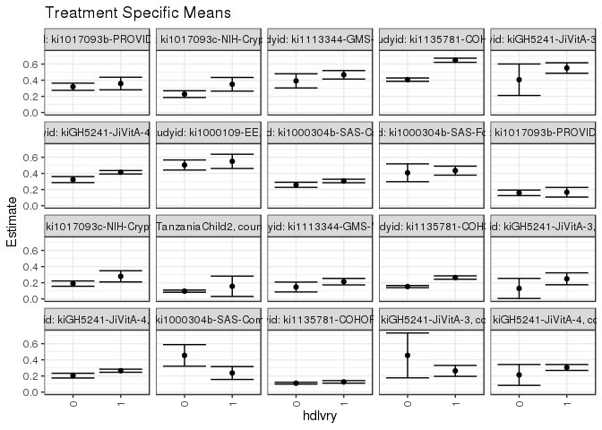

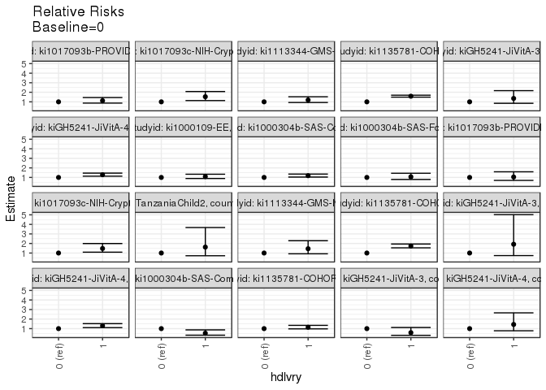

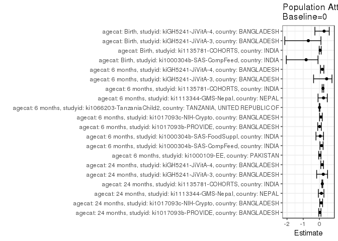

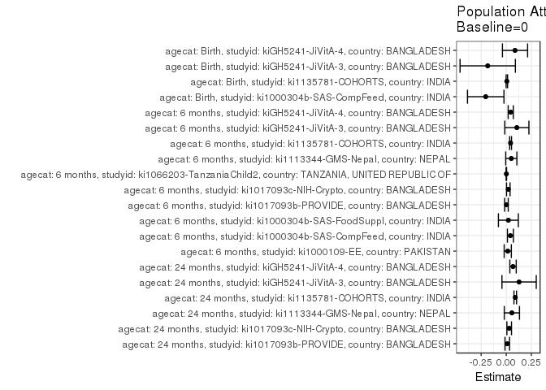

## Results Table

### Parameter: TSM

| agecat | studyid | country | intervention_level | baseline_level | estimate | ci_lower | ci_upper |
| --- | --- | --- | --- | --- | --- | --- | --- |
| Birth | ki1000304b-SAS-CompFeed | INDIA | 0 | NA | 0.4545455 | 0.3211332 | 0.5879577 |
| Birth | ki1000304b-SAS-CompFeed | INDIA | 1 | NA | 0.2366864 | 0.1571441 | 0.3162286 |
| Birth | ki1135781-COHORTS | INDIA | 0 | NA | 0.1106195 | 0.0992765 | 0.1219625 |
| Birth | ki1135781-COHORTS | INDIA | 1 | NA | 0.1264237 | 0.1108785 | 0.1419689 |
| Birth | kiGH5241-JiVitA-3 | BANGLADESH | 0 | NA | 0.4545455 | 0.1768203 | 0.7322707 |
| Birth | kiGH5241-JiVitA-3 | BANGLADESH | 1 | NA | 0.2629758 | 0.1953339 | 0.3306176 |
| Birth | kiGH5241-JiVitA-4 | BANGLADESH | 0 | NA | 0.2127660 | 0.0839179 | 0.3416140 |
| Birth | kiGH5241-JiVitA-4 | BANGLADESH | 1 | NA | 0.3053040 | 0.2686150 | 0.3419930 |
| 6 months | ki1000109-EE | PAKISTAN | 0 | NA | 0.5040323 | 0.4417211 | 0.5663434 |
| 6 months | ki1000109-EE | PAKISTAN | 1 | NA | 0.5491803 | 0.4607676 | 0.6375931 |
| 6 months | ki1000304b-SAS-CompFeed | INDIA | 0 | NA | 0.2585034 | 0.2268011 | 0.2902057 |
| 6 months | ki1000304b-SAS-CompFeed | INDIA | 1 | NA | 0.3061441 | 0.2844641 | 0.3278240 |
| 6 months | ki1000304b-SAS-FoodSuppl | INDIA | 0 | NA | 0.4078947 | 0.2972611 | 0.5185283 |
| 6 months | ki1000304b-SAS-FoodSuppl | INDIA | 1 | NA | 0.4342105 | 0.3784199 | 0.4900011 |
| 6 months | ki1017093b-PROVIDE | BANGLADESH | 0 | NA | 0.1593533 | 0.1248498 | 0.1938569 |
| 6 months | ki1017093b-PROVIDE | BANGLADESH | 1 | NA | 0.1666667 | 0.1069756 | 0.2263577 |
| 6 months | ki1017093c-NIH-Crypto | BANGLADESH | 0 | NA | 0.1895307 | 0.1568715 | 0.2221899 |
| 6 months | ki1017093c-NIH-Crypto | BANGLADESH | 1 | NA | 0.2795031 | 0.2101368 | 0.3488694 |
| 6 months | ki1066203-TanzaniaChild2 | TANZANIA, UNITED REPUBLIC OF | 0 | NA | 0.0963473 | 0.0830377 | 0.1096569 |
| 6 months | ki1066203-TanzaniaChild2 | TANZANIA, UNITED REPUBLIC OF | 1 | NA | 0.1562500 | 0.0304145 | 0.2820855 |
| 6 months | ki1113344-GMS-Nepal | NEPAL | 0 | NA | 0.1472868 | 0.0860731 | 0.2085006 |
| 6 months | ki1113344-GMS-Nepal | NEPAL | 1 | NA | 0.2135678 | 0.1732667 | 0.2538690 |
| 6 months | ki1135781-COHORTS | INDIA | 0 | NA | 0.1527586 | 0.1396637 | 0.1658535 |
| 6 months | ki1135781-COHORTS | INDIA | 1 | NA | 0.2645914 | 0.2442055 | 0.2849774 |
| 6 months | kiGH5241-JiVitA-3 | BANGLADESH | 0 | NA | 0.1298701 | 0.0058294 | 0.2539109 |
| 6 months | kiGH5241-JiVitA-3 | BANGLADESH | 1 | NA | 0.2491468 | 0.1753093 | 0.3229842 |
| 6 months | kiGH5241-JiVitA-4 | BANGLADESH | 0 | NA | 0.2042612 | 0.1750010 | 0.2335215 |
| 6 months | kiGH5241-JiVitA-4 | BANGLADESH | 1 | NA | 0.2649399 | 0.2459458 | 0.2839340 |
| 24 months | ki1017093b-PROVIDE | BANGLADESH | 0 | NA | 0.3194444 | 0.2754384 | 0.3634505 |
| 24 months | ki1017093b-PROVIDE | BANGLADESH | 1 | NA | 0.3586207 | 0.2804910 | 0.4367503 |
| 24 months | ki1017093c-NIH-Crypto | BANGLADESH | 0 | NA | 0.2276215 | 0.1860204 | 0.2692225 |
| 24 months | ki1017093c-NIH-Crypto | BANGLADESH | 1 | NA | 0.3495935 | 0.2652421 | 0.4339449 |
| 24 months | ki1113344-GMS-Nepal | NEPAL | 0 | NA | 0.3916667 | 0.3042384 | 0.4790950 |
| 24 months | ki1113344-GMS-Nepal | NEPAL | 1 | NA | 0.4668588 | 0.4143100 | 0.5194076 |
| 24 months | ki1135781-COHORTS | INDIA | 0 | NA | 0.4070757 | 0.3866958 | 0.4274556 |
| 24 months | ki1135781-COHORTS | INDIA | 1 | NA | 0.6470588 | 0.6213335 | 0.6727841 |
| 24 months | kiGH5241-JiVitA-3 | BANGLADESH | 0 | NA | 0.4057971 | 0.2108491 | 0.6007451 |
| 24 months | kiGH5241-JiVitA-3 | BANGLADESH | 1 | NA | 0.5507813 | 0.4857315 | 0.6158310 |
| 24 months | kiGH5241-JiVitA-4 | BANGLADESH | 0 | NA | 0.3233156 | 0.2861004 | 0.3605307 |
| 24 months | kiGH5241-JiVitA-4 | BANGLADESH | 1 | NA | 0.4141822 | 0.3928099 | 0.4355545 |

### Parameter: E(Y)

| agecat | studyid | country | intervention_level | baseline_level | estimate | ci_lower | ci_upper |
| --- | --- | --- | --- | --- | --- | --- | --- |
| Birth | ki1000304b-SAS-CompFeed | INDIA | NA | NA | 0.2500000 | 0.1698155 | 0.3301845 |
| Birth | ki1135781-COHORTS | INDIA | NA | NA | 0.1165317 | 0.1073518 | 0.1257117 |
| Birth | kiGH5241-JiVitA-3 | BANGLADESH | NA | NA | 0.2700000 | 0.2043793 | 0.3356207 |
| Birth | kiGH5241-JiVitA-4 | BANGLADESH | NA | NA | 0.3000000 | 0.2644043 | 0.3355957 |
| 6 months | ki1000109-EE | PAKISTAN | NA | NA | 0.5189189 | 0.4679396 | 0.5698982 |
| 6 months | ki1000304b-SAS-CompFeed | INDIA | NA | NA | 0.2997250 | 0.2767096 | 0.3227405 |
| 6 months | ki1000304b-SAS-FoodSuppl | INDIA | NA | NA | 0.4289474 | 0.3791199 | 0.4787748 |
| 6 months | ki1017093b-PROVIDE | BANGLADESH | NA | NA | 0.1612350 | 0.1313580 | 0.1911120 |
| 6 months | ki1017093c-NIH-Crypto | BANGLADESH | NA | NA | 0.2097902 | 0.1799252 | 0.2396552 |
| 6 months | ki1066203-TanzaniaChild2 | TANZANIA, UNITED REPUBLIC OF | NA | NA | 0.0973451 | 0.0840860 | 0.1106043 |
| 6 months | ki1113344-GMS-Nepal | NEPAL | NA | NA | 0.1973435 | 0.1633315 | 0.2313554 |
| 6 months | ki1135781-COHORTS | INDIA | NA | NA | 0.1955735 | 0.1842315 | 0.2069155 |
| 6 months | kiGH5241-JiVitA-3 | BANGLADESH | NA | NA | 0.2352941 | 0.1668442 | 0.3037440 |
| 6 months | kiGH5241-JiVitA-4 | BANGLADESH | NA | NA | 0.2486982 | 0.2326357 | 0.2647607 |
| 24 months | ki1017093b-PROVIDE | BANGLADESH | NA | NA | 0.3292894 | 0.2909105 | 0.3676684 |
| 24 months | ki1017093c-NIH-Crypto | BANGLADESH | NA | NA | 0.2568093 | 0.2190047 | 0.2946140 |
| 24 months | ki1113344-GMS-Nepal | NEPAL | NA | NA | 0.4475375 | 0.4023913 | 0.4926837 |
| 24 months | ki1135781-COHORTS | INDIA | NA | NA | 0.4964878 | 0.4800590 | 0.5129165 |
| 24 months | kiGH5241-JiVitA-3 | BANGLADESH | NA | NA | 0.5335628 | 0.4674074 | 0.5997182 |
| 24 months | kiGH5241-JiVitA-4 | BANGLADESH | NA | NA | 0.3907500 | 0.3719518 | 0.4095482 |

### Parameter: RR

| agecat | studyid | country | intervention_level | baseline_level | estimate | ci_lower | ci_upper |
| --- | --- | --- | --- | --- | --- | --- | --- |
| Birth | ki1000304b-SAS-CompFeed | INDIA | 0 | 0 | 1.0000000 | 1.0000000 | 1.0000000 |
| Birth | ki1000304b-SAS-CompFeed | INDIA | 1 | 0 | 0.5207101 | 0.3121948 | 0.8684928 |
| Birth | ki1135781-COHORTS | INDIA | 0 | 0 | 1.0000000 | 1.0000000 | 1.0000000 |
| Birth | ki1135781-COHORTS | INDIA | 1 | 0 | 1.1428702 | 0.9737860 | 1.3413133 |
| Birth | kiGH5241-JiVitA-3 | BANGLADESH | 0 | 0 | 1.0000000 | 1.0000000 | 1.0000000 |
| Birth | kiGH5241-JiVitA-3 | BANGLADESH | 1 | 0 | 0.5785467 | 0.2994589 | 1.1177370 |
| Birth | kiGH5241-JiVitA-4 | BANGLADESH | 0 | 0 | 1.0000000 | 1.0000000 | 1.0000000 |
| Birth | kiGH5241-JiVitA-4 | BANGLADESH | 1 | 0 | 1.4349288 | 0.7761467 | 2.6528759 |
| 6 months | ki1000109-EE | PAKISTAN | 0 | 0 | 1.0000000 | 1.0000000 | 1.0000000 |
| 6 months | ki1000109-EE | PAKISTAN | 1 | 0 | 1.0895738 | 0.8894126 | 1.3347809 |
| 6 months | ki1000304b-SAS-CompFeed | INDIA | 0 | 0 | 1.0000000 | 1.0000000 | 1.0000000 |
| 6 months | ki1000304b-SAS-CompFeed | INDIA | 1 | 0 | 1.1842942 | 1.0376684 | 1.3516386 |
| 6 months | ki1000304b-SAS-FoodSuppl | INDIA | 0 | 0 | 1.0000000 | 1.0000000 | 1.0000000 |
| 6 months | ki1000304b-SAS-FoodSuppl | INDIA | 1 | 0 | 1.0645161 | 0.7885142 | 1.4371264 |
| 6 months | ki1017093b-PROVIDE | BANGLADESH | 0 | 0 | 1.0000000 | 1.0000000 | 1.0000000 |
| 6 months | ki1017093b-PROVIDE | BANGLADESH | 1 | 0 | 1.0458937 | 0.6882258 | 1.5894400 |
| 6 months | ki1017093c-NIH-Crypto | BANGLADESH | 0 | 0 | 1.0000000 | 1.0000000 | 1.0000000 |
| 6 months | ki1017093c-NIH-Crypto | BANGLADESH | 1 | 0 | 1.4747116 | 1.0901648 | 1.9949043 |
| 6 months | ki1066203-TanzaniaChild2 | TANZANIA, UNITED REPUBLIC OF | 0 | 0 | 1.0000000 | 1.0000000 | 1.0000000 |
| 6 months | ki1066203-TanzaniaChild2 | TANZANIA, UNITED REPUBLIC OF | 1 | 0 | 1.6217376 | 0.7163325 | 3.6715252 |
| 6 months | ki1113344-GMS-Nepal | NEPAL | 0 | 0 | 1.0000000 | 1.0000000 | 1.0000000 |
| 6 months | ki1113344-GMS-Nepal | NEPAL | 1 | 0 | 1.4500132 | 0.9186313 | 2.2887729 |
| 6 months | ki1135781-COHORTS | INDIA | 0 | 0 | 1.0000000 | 1.0000000 | 1.0000000 |
| 6 months | ki1135781-COHORTS | INDIA | 1 | 0 | 1.7320884 | 1.5435253 | 1.9436871 |
| 6 months | kiGH5241-JiVitA-3 | BANGLADESH | 0 | 0 | 1.0000000 | 1.0000000 | 1.0000000 |
| 6 months | kiGH5241-JiVitA-3 | BANGLADESH | 1 | 0 | 1.9184300 | 0.7331200 | 5.0201519 |
| 6 months | kiGH5241-JiVitA-4 | BANGLADESH | 0 | 0 | 1.0000000 | 1.0000000 | 1.0000000 |
| 6 months | kiGH5241-JiVitA-4 | BANGLADESH | 1 | 0 | 1.2970641 | 1.1058448 | 1.5213484 |
| 24 months | ki1017093b-PROVIDE | BANGLADESH | 0 | 0 | 1.0000000 | 1.0000000 | 1.0000000 |
| 24 months | ki1017093b-PROVIDE | BANGLADESH | 1 | 0 | 1.1226387 | 0.8675523 | 1.4527281 |
| 24 months | ki1017093c-NIH-Crypto | BANGLADESH | 0 | 0 | 1.0000000 | 1.0000000 | 1.0000000 |
| 24 months | ki1017093c-NIH-Crypto | BANGLADESH | 1 | 0 | 1.5358546 | 1.1347332 | 2.0787700 |
| 24 months | ki1113344-GMS-Nepal | NEPAL | 0 | 0 | 1.0000000 | 1.0000000 | 1.0000000 |
| 24 months | ki1113344-GMS-Nepal | NEPAL | 1 | 0 | 1.1919799 | 0.9283203 | 1.5305235 |
| 24 months | ki1135781-COHORTS | INDIA | 0 | 0 | 1.0000000 | 1.0000000 | 1.0000000 |
| 24 months | ki1135781-COHORTS | INDIA | 1 | 0 | 1.5895295 | 1.4910909 | 1.6944669 |
| 24 months | kiGH5241-JiVitA-3 | BANGLADESH | 0 | 0 | 1.0000000 | 1.0000000 | 1.0000000 |
| 24 months | kiGH5241-JiVitA-3 | BANGLADESH | 1 | 0 | 1.3572824 | 0.8478887 | 2.1727090 |
| 24 months | kiGH5241-JiVitA-4 | BANGLADESH | 0 | 0 | 1.0000000 | 1.0000000 | 1.0000000 |
| 24 months | kiGH5241-JiVitA-4 | BANGLADESH | 1 | 0 | 1.2810464 | 1.1302471 | 1.4519656 |

### Parameter: PAR

| agecat | studyid | country | intervention_level | baseline_level | estimate | ci_lower | ci_upper |
| --- | --- | --- | --- | --- | --- | --- | --- |
| Birth | ki1000304b-SAS-CompFeed | INDIA | 0 | NA | -0.2045455 | -0.3860759 | -0.0230150 |
| Birth | ki1135781-COHORTS | INDIA | 0 | NA | 0.0059123 | -0.0012900 | 0.0131145 |
| Birth | kiGH5241-JiVitA-3 | BANGLADESH | 0 | NA | -0.1845455 | -0.4600090 | 0.0909181 |
| Birth | kiGH5241-JiVitA-4 | BANGLADESH | 0 | NA | 0.0872340 | -0.0380355 | 0.2125035 |
| 6 months | ki1000109-EE | PAKISTAN | 0 | NA | 0.0148867 | -0.0208440 | 0.0506173 |
| 6 months | ki1000304b-SAS-CompFeed | INDIA | 0 | NA | 0.0412216 | 0.0115269 | 0.0709164 |
| 6 months | ki1000304b-SAS-FoodSuppl | INDIA | 0 | NA | 0.0210526 | -0.0780768 | 0.1201821 |
| 6 months | ki1017093b-PROVIDE | BANGLADESH | 0 | NA | 0.0018816 | -0.0158593 | 0.0196226 |
| 6 months | ki1017093c-NIH-Crypto | BANGLADESH | 0 | NA | 0.0202595 | 0.0027767 | 0.0377424 |
| 6 months | ki1066203-TanzaniaChild2 | TANZANIA, UNITED REPUBLIC OF | 0 | NA | 0.0009979 | -0.0011377 | 0.0031334 |
| 6 months | ki1113344-GMS-Nepal | NEPAL | 0 | NA | 0.0500566 | -0.0053463 | 0.1054595 |
| 6 months | ki1135781-COHORTS | INDIA | 0 | NA | 0.0428149 | 0.0334094 | 0.0522204 |
| 6 months | kiGH5241-JiVitA-3 | BANGLADESH | 0 | NA | 0.1054240 | -0.0146524 | 0.2255004 |
| 6 months | kiGH5241-JiVitA-4 | BANGLADESH | 0 | NA | 0.0444370 | 0.0189931 | 0.0698809 |
| 24 months | ki1017093b-PROVIDE | BANGLADESH | 0 | NA | 0.0098450 | -0.0127319 | 0.0324218 |
| 24 months | ki1017093c-NIH-Crypto | BANGLADESH | 0 | NA | 0.0291879 | 0.0062351 | 0.0521406 |
| 24 months | ki1113344-GMS-Nepal | NEPAL | 0 | NA | 0.0558708 | -0.0199820 | 0.1317236 |
| 24 months | ki1135781-COHORTS | INDIA | 0 | NA | 0.0894121 | 0.0766037 | 0.1022205 |
| 24 months | kiGH5241-JiVitA-3 | BANGLADESH | 0 | NA | 0.1277657 | -0.0429816 | 0.2985131 |
| 24 months | kiGH5241-JiVitA-4 | BANGLADESH | 0 | NA | 0.0674344 | 0.0357627 | 0.0991062 |

### Parameter: PAF

| agecat | studyid | country | intervention_level | baseline_level | estimate | ci_lower | ci_upper |
| --- | --- | --- | --- | --- | --- | --- | --- |
| Birth | ki1000304b-SAS-CompFeed | INDIA | 0 | NA | -0.8181818 | -2.0446729 | -0.0857603 |
| Birth | ki1135781-COHORTS | INDIA | 0 | NA | 0.0507353 | -0.0130228 | 0.1104806 |
| Birth | kiGH5241-JiVitA-3 | BANGLADESH | 0 | NA | -0.6835017 | -2.1363257 | 0.0963381 |
| Birth | kiGH5241-JiVitA-4 | BANGLADESH | 0 | NA | 0.2907801 | -0.2779224 | 0.6063980 |
| 6 months | ki1000109-EE | PAKISTAN | 0 | NA | 0.0286878 | -0.0427352 | 0.0952187 |
| 6 months | ki1000304b-SAS-CompFeed | INDIA | 0 | NA | 0.1375315 | 0.0354689 | 0.2287942 |
| 6 months | ki1000304b-SAS-FoodSuppl | INDIA | 0 | NA | 0.0490798 | -0.2125598 | 0.2542641 |
| 6 months | ki1017093b-PROVIDE | BANGLADESH | 0 | NA | 0.0116702 | -0.1047054 | 0.1157862 |
| 6 months | ki1017093c-NIH-Crypto | BANGLADESH | 0 | NA | 0.0965704 | 0.0099200 | 0.1756373 |
| 6 months | ki1066203-TanzaniaChild2 | TANZANIA, UNITED REPUBLIC OF | 0 | NA | 0.0102507 | -0.0118966 | 0.0319133 |
| 6 months | ki1113344-GMS-Nepal | NEPAL | 0 | NA | 0.2536524 | -0.0840400 | 0.4861492 |
| 6 months | ki1135781-COHORTS | INDIA | 0 | NA | 0.2189197 | 0.1704333 | 0.2645722 |
| 6 months | kiGH5241-JiVitA-3 | BANGLADESH | 0 | NA | 0.4480519 | -0.3589853 | 0.7758279 |
| 6 months | kiGH5241-JiVitA-4 | BANGLADESH | 0 | NA | 0.1786784 | 0.0697751 | 0.2748322 |
| 24 months | ki1017093b-PROVIDE | BANGLADESH | 0 | NA | 0.0298977 | -0.0411411 | 0.0960893 |
| 24 months | ki1017093c-NIH-Crypto | BANGLADESH | 0 | NA | 0.1136557 | 0.0202907 | 0.1981232 |
| 24 months | ki1113344-GMS-Nepal | NEPAL | 0 | NA | 0.1248405 | -0.0624110 | 0.2790886 |
| 24 months | ki1135781-COHORTS | INDIA | 0 | NA | 0.1800892 | 0.1534463 | 0.2058937 |
| 24 months | kiGH5241-JiVitA-3 | BANGLADESH | 0 | NA | 0.2394577 | -0.1693897 | 0.5053620 |
| 24 months | kiGH5241-JiVitA-4 | BANGLADESH | 0 | NA | 0.1725769 | 0.0867346 | 0.2503505 |